# ER training-label sensitivity: strict exclusion versus near-zero treatment

2026-10-30

# Decision question

Can two training-only ER label treatments reduce negative CONUS respiration predictions while retaining skill on the **same physically valid held-out observations** and credible coverage, especially in headwaters? The reported comparisons are a sensitivity analysis, not a change to production outputs. A physically valid ER observation is raw StreamMetabolizer `ER <= 0`; the predicted target is positive respiration magnitude `-ER`. A prediction of zero is physically nonnegative, but the current downstream workflow requires strictly positive ER, so zero is counted separately and is **not usable coverage**.

**Summary.** Both QC variants remove negative predictions throughout the saved CONUS scaling grid while improving common-test R², RMSE, and MAE relative to the unfiltered six-predictor model. B has slightly better pooled skill and retains more training rows than A. Its CONUS ER distribution remains shifted upward from Maavara’s downloaded seven-predictor predictions, particularly in the upper tail. This favors B as the next candidate to validate, while leaving the production choice open.

# Design and provenance

The local fits use the archived 70/30 row split (`random_state=24`) and the same RF settings (500 trees, `max_features=5`, `max_depth=30`, `max_samples=0.4`, `oob_score=True`, `random_state=24`). The seven-predictor baseline includes `uparea`; the other three use the same six predictors without it. A removes raw `ER>0` **from training**. B removes raw `ER>0.5` from training and maps raw `ER` in `(0,0.5]` to zero respiration magnitude. All four are evaluated on the identical 134,336 original test rows with raw `ER<=0`. Training and test rows can share sites under this original row split; no site-held-out claim is made.

The [Maavara et al. Dryad archive](https://doi.org/10.5061/dryad.c2fqz61kx) contains the published network predictions and ER notebook. The final seven-predictor notebook cell reports test Pearson `r=0.8823235`, hence **Pearson r²=0.7784948**, on its unfiltered test set. It does not give RMSE, MAE, or bias in that cell. Pearson r² is not `sklearn` R² (`r2_score`). The published forest’s row-level held-out predictions were not saved locally, so it cannot be scored on the common valid-only test set. Its CONUS predictions are compared on paired network keys below. The [Appling et al. source assessment](https://pmc.ncbi.nlm.nih.gov/articles/PMC6289110/) and the earlier wrong-sign audit explain why these training treatments matter.

```
## Run UTC: 2026-10-30T20:23:56.148304+00:00
```

```
## Pinned versions: numpy 1.26.4; pandas 2.2.1; sklearn 1.4.2; scipy 1.13.0
```

# Training support

| model | train_n | train_sites |
| --- | --- | --- |
| Seven-feature local | 343250 | 355 |
| Six-feature unfiltered | 343250 | 355 |
| A: strict | 313012 | 353 |
| B: near-zero | 319263 | 354 |

| model | feature | p01 | median | p99 |
| --- | --- | --- | --- | --- |
| Seven-feature local | doy | 5.000 | 196.000 | 362.000 |
| Seven-feature local | temp.water | 0.383 | 16.008 | 30.302 |
| Seven-feature local | discharge | 0.009 | 3.470 | 2012.155 |
| Seven-feature local | shortwave | 33.253 | 196.965 | 353.444 |
| Seven-feature local | uparea | 27.992 | 1048.249 | 1075873.531 |
| Seven-feature local | TCC_mean | 0.302 | 35.653 | 81.960 |
| Seven-feature local | uparea_prop_wet | 0.000 | 0.014 | 0.461 |
| Six-feature unfiltered | doy | 5.000 | 196.000 | 362.000 |
| Six-feature unfiltered | temp.water | 0.383 | 16.008 | 30.302 |
| Six-feature unfiltered | discharge | 0.009 | 3.470 | 2012.155 |
| Six-feature unfiltered | shortwave | 33.253 | 196.965 | 353.444 |
| Six-feature unfiltered | TCC_mean | 0.302 | 35.653 | 81.960 |
| Six-feature unfiltered | uparea_prop_wet | 0.000 | 0.014 | 0.461 |
| A: strict | doy | 6.000 | 200.000 | 362.000 |
| A: strict | temp.water | 0.413 | 16.654 | 30.371 |
| A: strict | discharge | 0.009 | 2.985 | 2217.649 |
| A: strict | shortwave | 34.058 | 199.630 | 354.034 |
| A: strict | TCC_mean | 0.302 | 35.569 | 80.414 |
| A: strict | uparea_prop_wet | 0.000 | 0.014 | 0.461 |
| B: near-zero | doy | 6.000 | 200.000 | 362.000 |
| B: near-zero | temp.water | 0.400 | 16.531 | 30.354 |
| B: near-zero | discharge | 0.009 | 3.013 | 2172.750 |
| B: near-zero | shortwave | 33.901 | 198.741 | 353.857 |
| B: near-zero | TCC_mean | 0.302 | 35.607 | 81.960 |
| B: near-zero | uparea_prop_wet | 0.000 | 0.014 | 0.461 |

The source split, retained row counts, and retained sites were checked before fitting; see PREFLIGHT.md. Predictor quantiles show whether A or B materially shrink the range seen during training.

The two sites absent from A’s training set are `nwis_09326500` and `nwis_09327000`; both have low Appling site-minimum confidence. All 154 training rows at the first site and all 113 at the second have raw ER > 0. B also loses the first site; at the second it keeps just **three** near-zero rows, mapped to zero. Thus B’s one-site advantage should not be interpreted as meaningful retention of measured respiration support at that site.

# Common held-out skill

| model | n | r2 | rmse | mae | bias | negative_n | zero_n |
| --- | --- | --- | --- | --- | --- | --- | --- |
| Seven-feature local | 134336 | 0.7703 | 2.4321 | 1.4002 | -0.2023 | 1576 | 0 |
| Six-feature unfiltered | 134336 | 0.7687 | 2.4405 | 1.4063 | -0.2019 | 1562 | 0 |
| A: strict | 134336 | 0.7888 | 2.3318 | 1.3678 | 0.0317 | 0 | 0 |
| B: near-zero | 134336 | 0.7895 | 2.3280 | 1.3601 | -0.0082 | 0 | 0 |

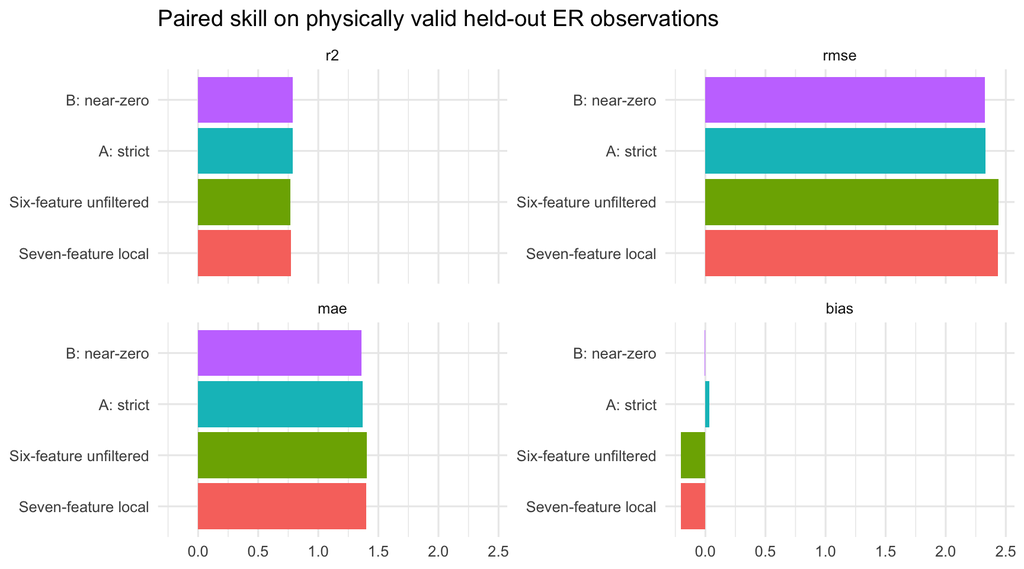

For direct paired changes, the reference is the **unfiltered six-predictor fit**. R² uses `sklearn.metrics.r2_score`; bias is predicted minus observed magnitude, so positive bias means overprediction.

| model | delta_r2 | delta_rmse | delta_mae | delta_bias | rmse_change_pct |
| --- | --- | --- | --- | --- | --- |
| A: strict | 0.0202 | -0.1087 | -0.0385 | 0.2337 | -4.4548 |
| B: near-zero | 0.0208 | -0.1125 | -0.0461 | 0.1937 | -4.6103 |

# Where skill changes

Bins below are fixed from the **pooled common held-out set**, not separately chosen for each model. Area bins (km²) are `<=50`, `50–100`, `100–1000`, and `>1000`; flow bins (m³/s) are `<=0.1`, `0.1–1`, `1–10`, `10–100`, and `>100`. Region bands are descriptive longitude groups, not ecological regions. Season follows day of year: winter Dec–Feb, spring Mar–May, summer Jun–Aug, fall Sep–Nov.

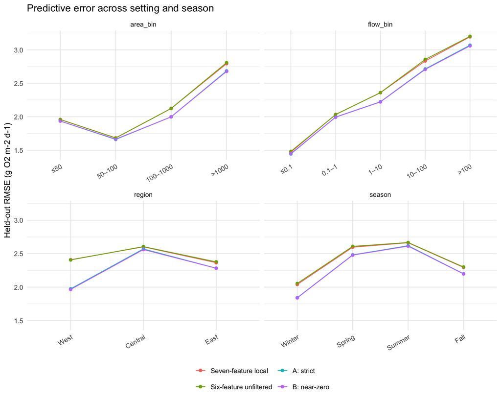

| grouping | level | model | n | r2 | rmse | mae | bias | negative_pct |
| --- | --- | --- | --- | --- | --- | --- | --- | --- |
| area_bin | 100–1000 | Seven-feature local | 43322 | 0.695 | 2.124 | 1.118 | -0.169 | 1.394 |
| area_bin | 100–1000 | Six-feature unfiltered | 43322 | 0.695 | 2.124 | 1.121 | -0.163 | 1.357 |
| area_bin | 100–1000 | A: strict | 43322 | 0.730 | 1.999 | 1.082 | 0.027 | 0.000 |
| area_bin | 100–1000 | B: near-zero | 43322 | 0.730 | 1.998 | 1.074 | -0.011 | 0.000 |
| area_bin | >1000 | Seven-feature local | 67068 | 0.768 | 2.794 | 1.698 | -0.269 | 1.339 |
| area_bin | >1000 | Six-feature unfiltered | 67068 | 0.766 | 2.808 | 1.708 | -0.273 | 1.349 |
| area_bin | >1000 | A: strict | 67068 | 0.786 | 2.685 | 1.659 | 0.043 | 0.000 |
| area_bin | >1000 | B: near-zero | 67068 | 0.787 | 2.678 | 1.649 | -0.002 | 0.000 |
| area_bin | ≤50 | Seven-feature local | 7887 | 0.791 | 1.960 | 1.154 | -0.120 | 0.799 |
| area_bin | ≤50 | Six-feature unfiltered | 7887 | 0.792 | 1.959 | 1.156 | -0.123 | 0.710 |
| area_bin | ≤50 | A: strict | 7887 | 0.796 | 1.936 | 1.152 | -0.002 | 0.000 |
| area_bin | ≤50 | B: near-zero | 7887 | 0.796 | 1.936 | 1.147 | -0.045 | 0.000 |
| area_bin | 50–100 | Seven-feature local | 16059 | 0.692 | 1.684 | 1.036 | -0.056 | 0.068 |
| area_bin | 50–100 | Six-feature unfiltered | 16059 | 0.692 | 1.683 | 1.041 | -0.050 | 0.081 |
| area_bin | 50–100 | A: strict | 16059 | 0.700 | 1.661 | 1.031 | 0.014 | 0.000 |
| area_bin | 50–100 | B: near-zero | 16059 | 0.698 | 1.665 | 1.030 | -0.010 | 0.000 |
| flow_bin | ≤0.1 | Seven-feature local | 13163 | 0.896 | 1.471 | 0.795 | 0.018 | 0.137 |
| flow_bin | ≤0.1 | Six-feature unfiltered | 13163 | 0.894 | 1.482 | 0.796 | 0.014 | 0.137 |
| flow_bin | ≤0.1 | A: strict | 13163 | 0.899 | 1.444 | 0.784 | 0.045 | 0.000 |
| flow_bin | ≤0.1 | B: near-zero | 13163 | 0.899 | 1.449 | 0.785 | 0.035 | 0.000 |
| flow_bin | 1–10 | Seven-feature local | 41551 | 0.762 | 2.360 | 1.285 | -0.213 | 1.146 |
| flow_bin | 1–10 | Six-feature unfiltered | 41551 | 0.762 | 2.361 | 1.289 | -0.209 | 1.148 |
| flow_bin | 1–10 | A: strict | 41551 | 0.789 | 2.224 | 1.241 | -0.001 | 0.000 |
| flow_bin | 1–10 | B: near-zero | 41551 | 0.789 | 2.222 | 1.235 | -0.038 | 0.000 |
| flow_bin | 0.1–1 | Seven-feature local | 33352 | 0.830 | 2.035 | 1.119 | -0.074 | 0.405 |
| flow_bin | 0.1–1 | Six-feature unfiltered | 33352 | 0.830 | 2.033 | 1.121 | -0.076 | 0.396 |
| flow_bin | 0.1–1 | A: strict | 33352 | 0.837 | 1.995 | 1.101 | 0.015 | 0.000 |
| flow_bin | 0.1–1 | B: near-zero | 33352 | 0.837 | 1.993 | 1.099 | -0.010 | 0.000 |
| flow_bin | 10–100 | Seven-feature local | 34659 | 0.697 | 2.834 | 1.813 | -0.325 | 2.141 |
| flow_bin | 10–100 | Six-feature unfiltered | 34659 | 0.692 | 2.856 | 1.825 | -0.332 | 2.109 |
| flow_bin | 10–100 | A: strict | 34659 | 0.722 | 2.714 | 1.770 | 0.076 | 0.000 |
| flow_bin | 10–100 | B: near-zero | 34659 | 0.723 | 2.708 | 1.755 | 0.016 | 0.000 |
| flow_bin | >100 | Seven-feature local | 11611 | 0.611 | 3.194 | 2.076 | -0.417 | 1.766 |
| flow_bin | >100 | Six-feature unfiltered | 11611 | 0.609 | 3.202 | 2.089 | -0.396 | 1.757 |
| flow_bin | >100 | A: strict | 11611 | 0.641 | 3.069 | 2.051 | 0.049 | 0.000 |
| flow_bin | >100 | B: near-zero | 11611 | 0.643 | 3.060 | 2.033 | -0.018 | 0.000 |
| season | Summer | Seven-feature local | 37466 | 0.783 | 2.663 | 1.550 | -0.151 | 0.472 |
| season | Summer | Six-feature unfiltered | 37466 | 0.783 | 2.667 | 1.550 | -0.151 | 0.467 |
| season | Summer | A: strict | 37466 | 0.791 | 2.619 | 1.542 | 0.027 | 0.000 |
| season | Summer | B: near-zero | 37466 | 0.792 | 2.613 | 1.534 | -0.005 | 0.000 |
| season | Fall | Seven-feature local | 38166 | 0.797 | 2.295 | 1.288 | -0.170 | 0.757 |
| season | Fall | Six-feature unfiltered | 38166 | 0.796 | 2.301 | 1.295 | -0.169 | 0.755 |
| season | Fall | A: strict | 38166 | 0.813 | 2.200 | 1.256 | 0.019 | 0.000 |
| season | Fall | B: near-zero | 38166 | 0.814 | 2.197 | 1.252 | -0.012 | 0.000 |
| season | Winter | Seven-feature local | 26340 | 0.738 | 2.040 | 1.150 | -0.234 | 2.263 |
| season | Winter | Six-feature unfiltered | 26340 | 0.735 | 2.055 | 1.159 | -0.234 | 2.278 |
| season | Winter | A: strict | 26340 | 0.787 | 1.843 | 1.085 | 0.068 | 0.000 |
| season | Winter | B: near-zero | 26340 | 0.787 | 1.840 | 1.077 | 0.019 | 0.000 |
| season | Spring | Seven-feature local | 32364 | 0.704 | 2.597 | 1.563 | -0.274 | 1.588 |
| season | Spring | Six-feature unfiltered | 32364 | 0.701 | 2.610 | 1.572 | -0.273 | 1.542 |
| season | Spring | A: strict | 32364 | 0.729 | 2.482 | 1.528 | 0.023 | 0.000 |
| season | Spring | B: near-zero | 32364 | 0.730 | 2.479 | 1.517 | -0.030 | 0.000 |
| region | East | Seven-feature local | 86789 | 0.735 | 2.365 | 1.426 | -0.186 | 1.074 |
| region | East | Six-feature unfiltered | 86789 | 0.732 | 2.378 | 1.435 | -0.190 | 1.096 |
| region | East | A: strict | 86789 | 0.753 | 2.283 | 1.400 | 0.028 | 0.000 |
| region | East | B: near-zero | 86789 | 0.753 | 2.283 | 1.394 | -0.011 | 0.000 |
| region | Central | Seven-feature local | 34146 | 0.829 | 2.602 | 1.344 | -0.160 | 0.568 |
| region | Central | Six-feature unfiltered | 34146 | 0.829 | 2.606 | 1.349 | -0.150 | 0.474 |
| region | Central | A: strict | 34146 | 0.834 | 2.571 | 1.343 | 0.044 | 0.000 |
| region | Central | B: near-zero | 34146 | 0.835 | 2.562 | 1.333 | 0.006 | 0.000 |
| region | West | Seven-feature local | 13401 | 0.715 | 2.410 | 1.378 | -0.417 | 3.358 |
| region | West | Six-feature unfiltered | 13401 | 0.715 | 2.407 | 1.370 | -0.414 | 3.350 |
| region | West | A: strict | 13401 | 0.808 | 1.975 | 1.221 | 0.027 | 0.000 |
| region | West | B: near-zero | 13401 | 0.810 | 1.966 | 1.209 | -0.029 | 0.000 |

# Paired CONUS predictions and coverage

All five variants are joined by identical COMID and month; the Maavara column is the downloaded seven-predictor prediction. The local seven- and six-predictor baseline network predictions are reused from the prior run, while A and B are newly generated. `finite & >0` defines usable reach-month coverage under the current downstream sign rule. Report missing, negative, and exact-zero separately. The source network starts at upstream area ~17.5 km² and contains no reaches `<=10 km²`. We therefore identify headwaters using stream **order 1**, and separately show the smallest available area band (`<=50 km²`).

| model | area_bin | n | missing | negative | zero | usable | usable_pct | negative_pct |
| --- | --- | --- | --- | --- | --- | --- | --- | --- |
| Seven-feature local | >1000 | 395532 | 36 | 18679 | 0 | 376817 | 95.27 | 4.72 |
| Seven-feature local | 100–1000 | 690732 | 0 | 51890 | 0 | 638842 | 92.49 | 7.51 |
| Seven-feature local | 50–100 | 411612 | 0 | 404 | 0 | 411208 | 99.90 | 0.10 |
| Seven-feature local | ≤50 | 603516 | 24 | 290 | 0 | 603202 | 99.95 | 0.05 |
| Six-feature unfiltered | >1000 | 395532 | 36 | 33823 | 0 | 361673 | 91.44 | 8.55 |
| Six-feature unfiltered | 100–1000 | 690732 | 0 | 49234 | 0 | 641498 | 92.87 | 7.13 |
| Six-feature unfiltered | 50–100 | 411612 | 0 | 28091 | 0 | 383521 | 93.18 | 6.82 |
| Six-feature unfiltered | ≤50 | 603516 | 24 | 41369 | 0 | 562123 | 93.14 | 6.85 |
| A: strict | >1000 | 395532 | 36 | 0 | 0 | 395496 | 99.99 | 0.00 |
| A: strict | 100–1000 | 690732 | 0 | 0 | 0 | 690732 | 100.00 | 0.00 |
| A: strict | 50–100 | 411612 | 0 | 0 | 0 | 411612 | 100.00 | 0.00 |
| A: strict | ≤50 | 603516 | 24 | 0 | 0 | 603492 | 100.00 | 0.00 |
| B: near-zero | >1000 | 395532 | 36 | 0 | 0 | 395496 | 99.99 | 0.00 |
| B: near-zero | 100–1000 | 690732 | 0 | 0 | 0 | 690732 | 100.00 | 0.00 |
| B: near-zero | 50–100 | 411612 | 0 | 0 | 0 | 411612 | 100.00 | 0.00 |
| B: near-zero | ≤50 | 603516 | 24 | 0 | 0 | 603492 | 100.00 | 0.00 |
| Maavara published | >1000 | 395532 | 0 | 18522 | 0 | 377010 | 95.32 | 4.68 |
| Maavara published | 100–1000 | 690732 | 0 | 52766 | 0 | 637966 | 92.36 | 7.64 |
| Maavara published | 50–100 | 411612 | 0 | 385 | 0 | 411227 | 99.91 | 0.09 |
| Maavara published | ≤50 | 603516 | 0 | 295 | 0 | 603221 | 99.95 | 0.05 |

**Stream-order 1 headwaters versus higher orders:**

| model | headwater | n | missing | negative | zero | usable | usable_pct |
| --- | --- | --- | --- | --- | --- | --- | --- |
| Seven-feature local | FALSE | 1038924 | 36 | 69098 | 0 | 969790 | 93.35 |
| Seven-feature local | TRUE | 1062468 | 24 | 2165 | 0 | 1060279 | 99.79 |
| Six-feature unfiltered | FALSE | 1038924 | 36 | 77952 | 0 | 960936 | 92.49 |
| Six-feature unfiltered | TRUE | 1062468 | 24 | 74565 | 0 | 987879 | 92.98 |
| A: strict | FALSE | 1038924 | 36 | 0 | 0 | 1038888 | 100.00 |
| A: strict | TRUE | 1062468 | 24 | 0 | 0 | 1062444 | 100.00 |
| B: near-zero | FALSE | 1038924 | 36 | 0 | 0 | 1038888 | 100.00 |
| B: near-zero | TRUE | 1062468 | 24 | 0 | 0 | 1062444 | 100.00 |
| Maavara published | FALSE | 1038924 | 0 | 69772 | 0 | 969152 | 93.28 |
| Maavara published | TRUE | 1062468 | 0 | 2196 | 0 | 1060272 | 99.79 |

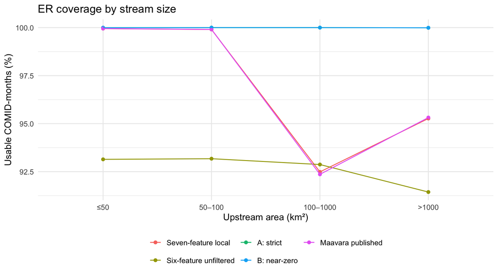

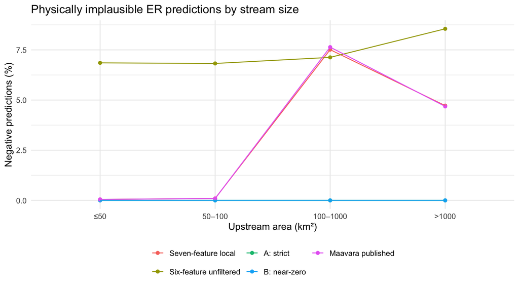

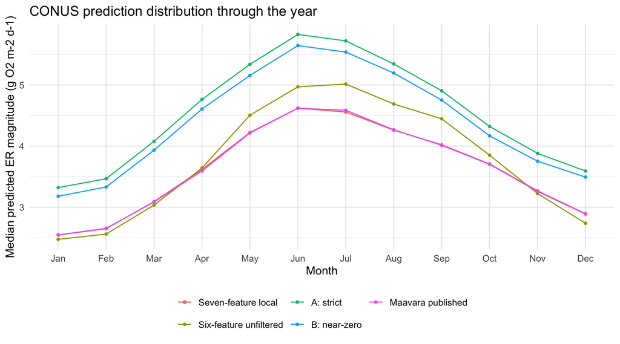

| month | model | p05 | median | p95 |
| --- | --- | --- | --- | --- |
| Jan | Seven-feature local | 0.095 | 2.546 | 10.298 |
| Jan | Six-feature unfiltered | -1.060 | 2.475 | 16.616 |
| Jan | A: strict | 1.230 | 3.321 | 18.339 |
| Jan | B: near-zero | 1.109 | 3.180 | 18.190 |
| Jan | Maavara published | 0.098 | 2.549 | 10.295 |
| Feb | Seven-feature local | 0.036 | 2.650 | 10.657 |
| Feb | Six-feature unfiltered | -1.180 | 2.562 | 17.405 |
| Feb | A: strict | 1.292 | 3.467 | 19.114 |
| Feb | B: near-zero | 1.166 | 3.332 | 18.903 |
| Feb | Maavara published | 0.024 | 2.655 | 10.657 |
| Mar | Seven-feature local | -0.210 | 3.093 | 10.845 |
| Mar | Six-feature unfiltered | -1.351 | 3.036 | 18.166 |
| Mar | A: strict | 1.438 | 4.079 | 20.021 |
| Mar | B: near-zero | 1.333 | 3.935 | 20.068 |
| Mar | Maavara published | -0.224 | 3.088 | 10.860 |
| Apr | Seven-feature local | 0.289 | 3.619 | 11.869 |
| Apr | Six-feature unfiltered | -1.414 | 3.642 | 19.897 |
| Apr | A: strict | 1.668 | 4.764 | 20.469 |
| Apr | B: near-zero | 1.569 | 4.607 | 20.575 |
| Apr | Maavara published | 0.253 | 3.593 | 11.857 |
| May | Seven-feature local | 0.712 | 4.223 | 13.749 |
| May | Six-feature unfiltered | -0.814 | 4.506 | 20.675 |
| May | A: strict | 1.920 | 5.338 | 21.232 |
| May | B: near-zero | 1.833 | 5.156 | 21.060 |
| May | Maavara published | 0.701 | 4.215 | 13.737 |
| Jun | Seven-feature local | 1.290 | 4.620 | 16.208 |
| Jun | Six-feature unfiltered | 0.115 | 4.969 | 21.420 |
| Jun | A: strict | 2.122 | 5.826 | 21.855 |
| Jun | B: near-zero | 2.049 | 5.644 | 21.758 |
| Jun | Maavara published | 1.301 | 4.619 | 16.221 |
| Jul | Seven-feature local | 1.629 | 4.557 | 18.786 |
| Jul | Six-feature unfiltered | 0.565 | 5.014 | 23.310 |
| Jul | A: strict | 2.033 | 5.721 | 23.413 |
| Jul | B: near-zero | 1.975 | 5.537 | 23.238 |
| Jul | Maavara published | 1.649 | 4.586 | 18.772 |
| Aug | Seven-feature local | 1.641 | 4.261 | 16.663 |
| Aug | Six-feature unfiltered | 0.652 | 4.688 | 22.006 |
| Aug | A: strict | 1.845 | 5.343 | 22.017 |
| Aug | B: near-zero | 1.788 | 5.195 | 22.000 |
| Aug | Maavara published | 1.631 | 4.267 | 16.650 |
| Sep | Seven-feature local | 1.439 | 4.022 | 13.192 |
| Sep | Six-feature unfiltered | 0.568 | 4.446 | 20.123 |
| Sep | A: strict | 1.634 | 4.905 | 20.612 |
| Sep | B: near-zero | 1.581 | 4.752 | 20.694 |
| Sep | Maavara published | 1.438 | 4.014 | 13.171 |
| Oct | Seven-feature local | 1.169 | 3.708 | 11.967 |
| Oct | Six-feature unfiltered | -0.380 | 3.851 | 20.001 |
| Oct | A: strict | 1.447 | 4.321 | 21.318 |
| Oct | B: near-zero | 1.399 | 4.167 | 21.358 |
| Oct | Maavara published | 1.170 | 3.702 | 11.965 |
| Nov | Seven-feature local | 0.766 | 3.268 | 11.461 |
| Nov | Six-feature unfiltered | -1.042 | 3.224 | 18.608 |
| Nov | A: strict | 1.293 | 3.882 | 20.408 |
| Nov | B: near-zero | 1.233 | 3.753 | 20.197 |
| Nov | Maavara published | 0.784 | 3.259 | 11.468 |
| Dec | Seven-feature local | 0.298 | 2.895 | 10.267 |
| Dec | Six-feature unfiltered | -1.241 | 2.738 | 17.484 |
| Dec | A: strict | 1.217 | 3.593 | 19.241 |
| Dec | B: near-zero | 1.060 | 3.494 | 19.246 |
| Dec | Maavara published | 0.297 | 2.889 | 10.277 |

| area_bin | A_gain | A_loss | B_gain | B_loss |
| --- | --- | --- | --- | --- |
| >1000 | 33823 | 0 | 33823 | 0 |
| 100–1000 | 49234 | 0 | 49234 | 0 |
| 50–100 | 28091 | 0 | 28091 | 0 |
| ≤50 | 41369 | 0 | 41369 | 0 |

# Interpretation and recommendation

Relative to the unfiltered six-predictor fit, A changes held-out RMSE by **-4.45%** and B by **-4.61%**. Across all COMID-months, the unfiltered fit has **152,517** negative predictions and **1,948,815** usable predictions; A has **0** and **2,101,332**, and B has **0** and **2,101,332**, respectively.

**Recommendation:** Advance **B** as the provisional QC candidate for scientific review. It retains 6,251 more training rows than A, has slightly better pooled R²/RMSE/MAE and smaller absolute bias, and provides the same complete positive-prediction coverage. Its extra retained site contributes only three zero-mapped observations, so that site-count difference has little practical value. Both A and B lower RMSE relative to the unfiltered six-predictor fit in every displayed area, flow, season, and region group. The practical difference between A and B is small. Neither establishes agreement with the published seven-predictor CONUS distribution: both retain the elevated upper tail associated with removing `uparea`, and the monthly median ER is higher than the downloaded Maavara predictions. Before replacing production, decide whether that distribution shift is scientifically credible and consider a site-held-out check, because the original row-wise split shares sites across training and testing. No downstream scripts were rerun.